# Rendimiento del combustible en autos comerciales.

Realizaremos un análisis de diferentes vehículos para poder realizar la prediccion sobre si la cantidad de cilindros de un auto es mayor a 4 cilindros(1) o menor o igual a 4 cilindros(0) a través de, la función logistica, arboles de decisión y de la función discriminante.

Para realizar dicho estudio obtuvimos información del [UCI Machine Learning Repository](https://archive.ics.uci.edu/) específicamente de [Auto MPG](https://archive.ics.uci.edu/dataset/9/auto+mpg) de un estudio de Quinlan, R. (1993).

La base de datos tenía algunos valores de la variable de interés como NaN, se eliminaron esas filas ya que considero que cualquier manera de conseguir ese valor añadiría incertidumbre a nuestro modelo. Estaríamos construyendo nuestro modelo en terreno que no es firme.

Ajustaremos los datos para poder realizar nuestro objetivo.

```python
import pandas as pd

# Abrimos la base de datos.
df = pd.read_csv("auto2-mpg.data-original",  sep='\s+')

# Asignamos nombres a las columnas
df.columns = ["MPG", "Cylinders", "Displacement", "Horsepower", "Weight", "Acceleration", "Model_year", "Origin", "Car name"]

# Imprimimos la base de datos para visualizar nuestra información
display(df.head(3))

#Tiramos el nombre del modelo ya que es unico por cada auto y no nos aportara informacion relevante.
df = df.drop(columns=["Car name"])

print("\nDatos modificados:")
display(df.head(2))

# Creamos la variable binaria de cilindros y soltamos la variable de cilindros
df["Cylinders_binary"] = (df["Cylinders"]>4 ).astype(int)
df = df.drop(["Cylinders"], axis = 1)
df = df.drop(["Horsepower"], axis = 1)


# Identificar variable categórica y convertirla en dummies
categorical_vars = ["Origin"]
df = pd.get_dummies(df, columns=categorical_vars, drop_first=True).astype(int)
df = df.rename(columns={"Origin_2.0":"Europa"})
df = df.rename(columns={"Origin_3.0":"Asia"})

# Verificamos
display(df.head(2))
```

|  | MPG | Cylinders | Displacement | Horsepower | Weight | Acceleration | Model_year | Origin | Car name |
| --- | --- | --- | --- | --- | --- | --- | --- | --- | --- |
| 0 | 15.0 | 8.0 | 350.0 | 165.0 | 3693.0 | 11.5 | 70.0 | 1.0 | buick skylark 320 |
| 1 | 18.0 | 8.0 | 318.0 | 150.0 | 3436.0 | 11.0 | 70.0 | 1.0 | plymouth satellite |
| 2 | 16.0 | 8.0 | 304.0 | 150.0 | 3433.0 | 12.0 | 70.0 | 1.0 | amc rebel sst |

```
Datos modificados:
```

|  | MPG | Cylinders | Displacement | Horsepower | Weight | Acceleration | Model_year | Origin |
| --- | --- | --- | --- | --- | --- | --- | --- | --- |
| 0 | 15.0 | 8.0 | 350.0 | 165.0 | 3693.0 | 11.5 | 70.0 | 1.0 |
| 1 | 18.0 | 8.0 | 318.0 | 150.0 | 3436.0 | 11.0 | 70.0 | 1.0 |

|  | MPG | Displacement | Weight | Acceleration | Model_year | Cylinders_binary | Europa | Asia |
| --- | --- | --- | --- | --- | --- | --- | --- | --- |
| 0 | 15 | 350 | 3693 | 11 | 70 | 1 | 0 | 0 |
| 1 | 18 | 318 | 3436 | 11 | 70 | 1 | 0 | 0 |

Ahora separaremos los datos con una proporcion de 80% para entrenamiento y 20% para prueba. Verificaremos la proporción de los datos de intéres para evitar un entrenamiento errado.

```python
from sklearn.model_selection import train_test_split
from sklearn.preprocessing import StandardScaler

# Obtenemos el eje x
x = df.drop(["Cylinders_binary"], axis=1)

columns_to_normalize = x.columns.difference(["Model_year", "Europa", "Asia"] )
x[columns_to_normalize] = StandardScaler().fit_transform(x[columns_to_normalize])

# Obtenemos el eje y
y = df["Cylinders_binary"]

# Separamos los datos en un 80% - 20% en entrenamiento y prueba
x_train, x_test, y_train, y_test = train_test_split(x, y, test_size=0.2, stratify=y, random_state=57)

#Obtenemos las proporciones
train_distribution = y_train.value_counts(normalize=True)
test_distribution = y_test.value_counts(normalize=True)
original_distribution = y.value_counts(normalize=True)

# Verificamos que las proporciones son similares
print("Distribucion de los datos originales", original_distribution)
print("Distribucion de los datos de entrenamiento", train_distribution)
print("Distribucion de los datos de prueba", test_distribution)
```

```
Distribucion de los datos originales Cylinders_binary
0    0.519182
1    0.480818
Name: proportion, dtype: float64
Distribucion de los datos de entrenamiento Cylinders_binary
0    0.519231
1    0.480769
Name: proportion, dtype: float64
Distribucion de los datos de prueba Cylinders_binary
0    0.518987
1    0.481013
Name: proportion, dtype: float64
```

Ahora realizaremos una función logistica con la función GLM de statsmodels, con todas las variables de entrada, imprimiremos el resumen en la consola. Buscaremos las 2 variables más relevantes y eliminaremos las demás variables en los datos de entrenamiento y de prueba.

```python
import numpy as np
import statsmodels.api as sm

glm = sm.GLM(y_train, sm.add_constant(x_train), family=sm.families.Binomial()).fit()

print(glm.summary())
```

```
                 Generalized Linear Model Regression Results
==============================================================================
Dep. Variable:       Cylinders_binary   No. Observations:                  312
Model:                            GLM   Df Residuals:                      304
Model Family:                Binomial   Df Model:                            7
Link Function:                  Logit   Scale:                          1.0000
Method:                          IRLS   Log-Likelihood:                -12.418
Date:                Thu, 20 Mar 2025   Deviance:                       24.836
Time:                        01:50:19   Pearson chi2:                     137.
No. Iterations:                    12   Pseudo R-squ. (CS):             0.7289
Covariance Type:            nonrobust
================================================================================
                   coef    std err          z      P>|z|      [0.025      0.975]
--------------------------------------------------------------------------------
const           16.2391     22.180      0.732      0.464     -27.233      59.711
MPG              0.3285      1.494      0.220      0.826      -2.600       3.257
Displacement    26.3225      9.545      2.758      0.006       7.614      45.031
Weight          -0.5114      3.622     -0.141      0.888      -7.610       6.587
Acceleration    -1.0581      0.909     -1.164      0.244      -2.840       0.724
Model_year      -0.1128      0.273     -0.414      0.679      -0.647       0.421
Europa           7.2939      3.200      2.279      0.023       1.022      13.566
Asia             5.5660      2.306      2.414      0.016       1.047      10.085
================================================================================
```

```python
x_train = x_train[["Displacement", "Asia"]]
x_test = x_test[["Displacement", "Asia"]]
```

Ahora generaremos un modelo utilizando el linear discriminant analysis. Graficaremos la función discriminante tomanto en cuenta las dos variables que utilizaremos en el entrenamiento.

```python
from sklearn.discriminant_analysis import LinearDiscriminantAnalysis

lda = LinearDiscriminantAnalysis().fit(x_train,y_train)
```

[output not shown]

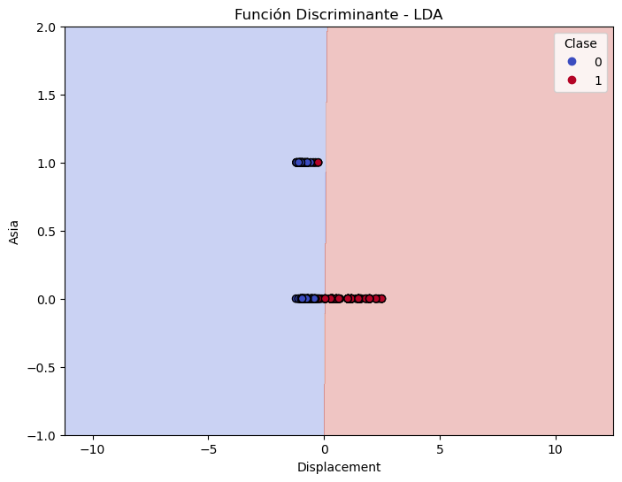

```python
import matplotlib.pyplot as plt
%matplotlib inline

# Crear una malla de puntos para la visualización
x_min, x_max = x_train["Displacement"].min() - 10, x_train["Displacement"].max() + 10
y_min, y_max = x_train["Asia"].min() - 1, x_train["Asia"].max() + 1
xx, yy = np.meshgrid(np.linspace(x_min, x_max, 1000),
                     np.linspace(y_min, y_max, 1000))

# Predecir clases para cada punto en la malla
Z = lda.predict(np.c_[xx.ravel(), yy.ravel()])
Z = Z.reshape(xx.shape)

# Graficar la función discriminante
plt.figure(figsize=(8, 6))
plt.contourf(xx, yy, Z, alpha=0.3, cmap="coolwarm")  # Fondos de color según la clase
scatter = plt.scatter(x_train["Displacement"], x_train["Asia"], c=y_train, cmap="coolwarm", edgecolor="k")

# Etiquetas y leyenda
plt.xlabel("Displacement")
plt.ylabel("Asia")
plt.title("Función Discriminante - LDA")
plt.legend(*scatter.legend_elements(), title="Clase")
plt.show()
```

Ahora generaremos un modelo usando arboles de decisión, primero entrenaremos y luego podaremos el arbol con el valor optimo de $\alpha$.

```python
x_train2, x_test2, y_train2, y_test2 = train_test_split(x_train, y_train,test_size=0.2, random_state=57)

#Obtenemos las proporciones
train_distribution2 = y_train2.value_counts(normalize=True)
test_distribution2 = y_test2.value_counts(normalize=True)


# Verificamos que las proporciones son similares
print("Distribucion de los datos originales", original_distribution)
print("Distribucion de los datos de entrenamiento", train_distribution2)
print("Distribucion de los datos de prueba", test_distribution2)

# Importar librería
from sklearn.tree import DecisionTreeClassifier as DTC
# Crear y entrenar modelo
tree = DTC().fit(x_train2,y_train2)
```

```
Distribucion de los datos originales Cylinders_binary
0    0.519182
1    0.480818
Name: proportion, dtype: float64
Distribucion de los datos de entrenamiento Cylinders_binary
0    0.542169
1    0.457831
Name: proportion, dtype: float64
Distribucion de los datos de prueba Cylinders_binary
1    0.571429
0    0.428571
Name: proportion, dtype: float64
```

Graficaremos el árbol de decisión

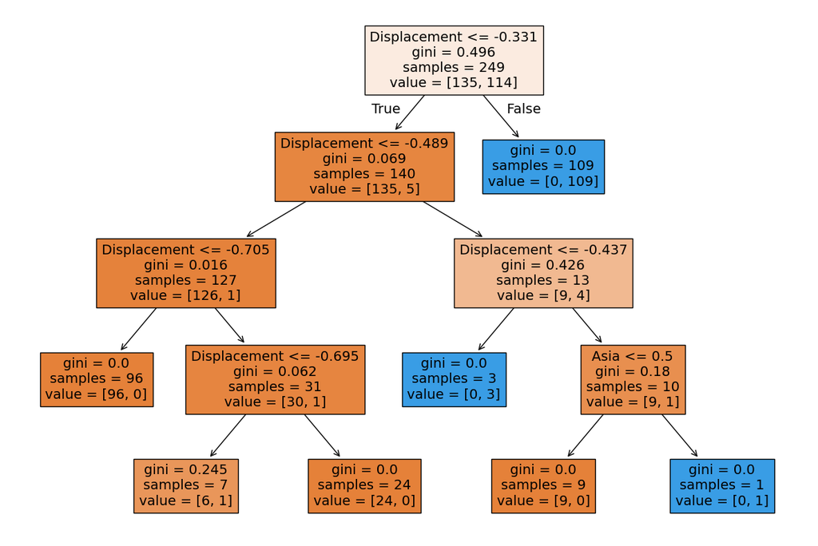

```python
# Importa la librería para generar gráficas
import matplotlib.pyplot as plt
# Función mágica
%matplotlib inline
# Importa plot_tree
from sklearn.tree import plot_tree
# Define el tamaño de la figura
plt.figure(figsize=(15, 10))
# Genera la gráfica del árbol de decisión
plot_tree(tree, filled=True, feature_names=x_train.columns);
```

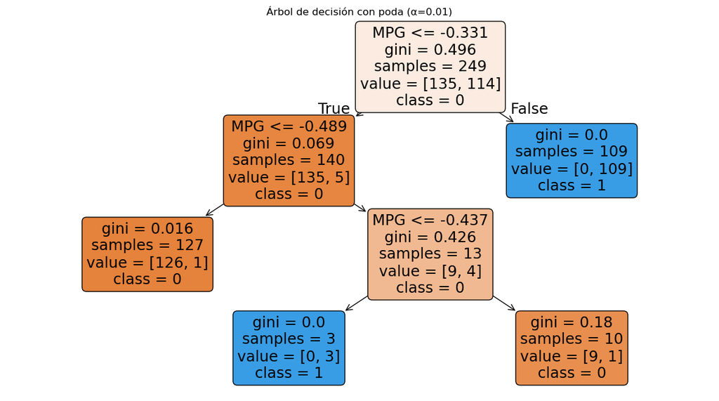

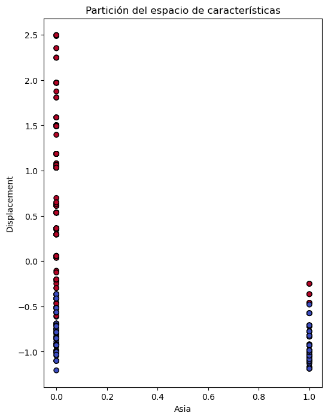

```python
from sklearn.metrics import accuracy_score

# Usamos ccp_alpha para la poda
alphas = np.arange(0.01, 0.1, 0.01)  # Probamos con menos valores de α para hacerlo más rápido

# Restablecemos el proceso de búsqueda de α
best_alpha = None
best_accuracy = 0

# Búsqueda del mejor α mediante validación cruzada con los datos de entrenamiento
for alpha in alphas:
    accuracies = []

    # Entrenamos el modelo con los datos de entrenamiento (X_train2, y_train2)
    clf = DTC(ccp_alpha=alpha)
    clf.fit(x_train2, y_train2)
    y_pred = clf.predict(x_test2)  # Realizamos predicciones con los datos de prueba
    accuracies.append(accuracy_score(y_test2, y_pred))  # Calculamos la precisión

    # Calculamos la media de la precisión para el valor de α actual
    mean_accuracy = np.mean(accuracies)

    if mean_accuracy > best_accuracy:
        best_accuracy = mean_accuracy
        best_alpha = alpha

# Entrenamos el modelo con el mejor α encontrado
clf = DTC(ccp_alpha=best_alpha)
clf.fit(x_train2, y_train2)  # Entrenamos con los datos de entrenamiento

# Visualizamos el árbol de decisión resultante
plt.figure(figsize=(15,8))
plot_tree(clf, filled=True, feature_names=x.columns, class_names=['0', '1'], rounded=True)
plt.title(f'Árbol de decisión con poda (α={best_alpha})')
plt.show()

# Visualizamos la partición en un gráfico de variable 1 (Asia) vs variable 2 (Displacement)
plt.figure(figsize=(6,8))
plt.scatter(x['Asia'], x['Displacement'], c=y, cmap='coolwarm', edgecolors='k')
plt.xlabel('Asia')
plt.ylabel('Displacement')
plt.title('Partición del espacio de características')
plt.show()
```

Ahora generaremos las siguientes metricas para el modelo generado con los arboles de decisión: Accuracy, F1-score, AUC, Matriz de confusión.

```python
from sklearn.metrics import confusion_matrix,accuracy_score,  f1_score, roc_auc_score, recall_score

yhat_tree = tree.predict(x_test)

accuracy_tree = accuracy_score(y_test, yhat_tree)
f1_tree = f1_score(y_test, yhat_tree)
auc_tree = roc_auc_score(y_test, yhat_tree)
Matrix_tree = confusion_matrix(y_test, yhat_tree)
sensitivity_tree = recall_score(y_test, yhat_tree)  # Sensibilidad (recall para clase 1)
specificity_tree = Matrix_tree[0, 0] / (Matrix_tree[0, 0] + Matrix_tree[0, 1])  # Especificidad (TN / (TN + FP))
print("Arbol de Decisión:")
print("Accuracy:", accuracy_tree)
print("F1-score:", f1_tree)
print("AUC-ROC:", auc_tree)
print("Senitivity: ", sensitivity_tree)
print("Specificity", specificity_tree)

print("Matriz de confusión:\n", Matrix_tree)


yhat_clf = clf.predict(x_test)

accuracy_clf = accuracy_score(y_test, yhat_clf)
f1_clf = f1_score(y_test, yhat_clf)
auc_clf = roc_auc_score(y_test, yhat_clf)
Matrix_clf = confusion_matrix(y_test, yhat_clf)
sensitivity_clf = recall_score(y_test, yhat_clf)  # Sensibilidad (recall para clase 1)
specificity_clf = Matrix_clf[0, 0] / (Matrix_clf[0, 0] + Matrix_clf[0, 1])  # Especificidad (TN / (TN + FP))

print("\n Arbol podado:")
print("Accuracy del árbol podado:", accuracy_clf)
print("F1-score del árbol podado:", f1_clf)
print("Senitivity: ", sensitivity_clf)
print("Specificity", specificity_clf)
print("Matriz de confusión:\n", Matrix_clf)
```

```
Arbol de Decisión:
Accuracy: 0.9873417721518988
F1-score: 0.987012987012987
AUC-ROC: 0.9878048780487805
Senitivity:  1.0
Specificity 0.975609756097561
Matriz de confusión:
 [[40  1]
 [ 0 38]]

 Arbol podado:
Accuracy del árbol podado: 1.0
F1-score del árbol podado: 1.0
Senitivity:  1.0
Specificity 1.0
Matriz de confusión:
 [[41  0]
 [ 0 38]]
```

Podemos observar que el arbol de decision podado es mejor que el que no tuvo ningún parametro para optimizar su tamaño, es de hecho un modelo ideal, recalcando que esto se probó en datos de prueba que no se habían usado ni para obtener alpha.

Ahora generaremos esas metricas para el modelo discriminante.

```python
# Predicciones con la funcion discriminante
yhat_lda = lda.predict(x_test)
accuracy_lda = accuracy_score(y_test, yhat_lda)
f1_lda = f1_score(y_test, yhat_lda)
auc_lda = roc_auc_score(y_test, yhat_lda)
Matrix_lda = confusion_matrix(y_test, yhat_lda)
sensitivity_lda = recall_score(y_test, yhat_lda)  # Sensibilidad (recall para clase 1)
specificity_lda = Matrix_lda[0, 0] / (Matrix_lda[0, 0] + Matrix_lda[0, 1])  # Especificidad (TN / (TN + FP))
print("Arbol de decisión LDA:")
print("F1-score:", f1_lda)
print("Accuracy:", accuracy_lda)
print("AUC:", auc_lda)
print("Senitivity: ", sensitivity_clf)
print("Specificity", specificity_clf)
print("Matriz de confusión:\n", Matrix_lda)
```

[output not shown]

Podemos observar que ambos modelos tienen muy buenos resultados, evitamos la fuga de datos para ambos modelos, ambos se prueban conn datos que no se habían utilizado previamente, vemos que el arbol optimizado tuvo mejores resultados, ideales, es algo de esperar ya que no es una tarea tan complicada, sin embargo aunque el modelo se probo con datos de prueba los arboles de decisión suelen tener un sobre ajuste, es algo que se debe de tomar en cuenta.